# HW 2

# 1) A little introductory brain teaser. Which is more probable when rolling 2 six-sided dice: rolling snake eyes (two ones) or rolling sevens (dice sum to seven)? What is the ratio of the probabilities?

# 1)

## P(Snake Eyes) = P(1,1) = 1/36

## P(Sum = 7) = 6/36

## The ratio of probabilities:

## P(Snake Eyes) / P(Sum = 7) = 1/6

## P(Sum = 7) > P(Snake Eyes)

# 2) Following what we did in class show how to use the convolution operator to determine the probability of the sum of 2 six sided dice. Do both analytically (math & counting) and numerically (computer program). Beware the implicit definition of the values (x-axis on histogram).

```python
import numpy as np
import matplotlib
import matplotlib.pyplot as plt
import scipy
```

```python
from scipy import stats
```

# When we roll two dices (six sides) our sum will have a range from 2 to 12.

```python
probability_sum_of_two = np.array([1/6] * 6)
sum_of_probabilities = np.convolve(probability_sum_of_two, probability_sum_of_two)
```

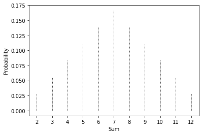

```python
plt.xticks(range(2, 13))
plt.vlines(range(2, 13), 0, sum_of_probabilities, linestyles ="dotted", colors = "k", linewidth=1);
plt.xlabel("Sum")
plt.ylabel("Probability")
```

# 3) Calculate the mean and the variance of the distribution in problem 2. Hint: this is surprisingly tricky, make sure your result makes sense.

# Mean = Probability * Sum of Elements

# Variance = (Sum of Differences - Mean)^2 * Sum of Probabilities

```python
sum_of_elements = np.arange(2,13,1)
mean = sum(sum_of_elements * sum_of_probabilities)
variance = sum((np.arange(2, 13) - mean)**2 * sum_of_probabilities)
```

```python
print("Mean: ", f"{mean}")
print("variance: ", f"{variance}")
```

```
Mean:  7.0
variance:  5.833333333333334
```

# 4) Repeat 2, and graph the average of 10 dice. Is this is a Gaussian distribution? Explain in depth.

```python
def average_probability_of_10_dice(throws, width=2):
    average_probability = np.copy(probability_sum_of_two)
    for i in range(throws):
        average_probability = np.convolve(probability_sum_of_two, average_probability)
    possible_average = np.linspace(1, 6, len(average_probability))
    plt.vlines(possible_average, 0, average_probability, linestyles ="dotted", colors = "k", linewidth=width);
    plt.xlabel("Possible Average")
    plt.ylabel("Probability")
    plt.xlim(1, 6)
    plt.ylim(0, 0.08)
    return possible_average, average_probability
```

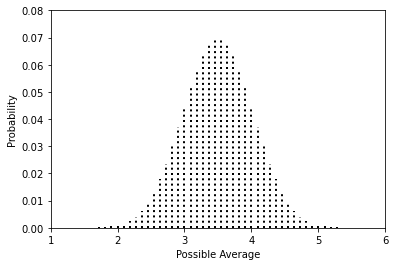

```python
average_probability_of_10_dice(10);
```

# When we roll 10 dice, we expect to get an average of 3.5 for each.

# The plot above does indeed look like a Gaussian distribution from this scale, but it is not completely continuous if we zoom into the distribution. If we rolled more than 10 dices, we will get a Gaussian distribution that is a lot more continuous and smoother.

```python
def average_probability_of_100_dice(throws, width=1):
    average_probability = np.copy(probability_sum_of_two)
    for i in range(throws):
        average_probability = np.convolve(probability_sum_of_two, average_probability)
    possible_average = np.linspace(1, 6, len(average_probability))
    plt.vlines(possible_average, 0, average_probability, linestyles ="dotted", colors = "k", linewidth=width);
    plt.xlabel("Possible Average")
    plt.ylabel("Probability")
    plt.xlim(2.75, 4.2)
    plt.ylim(0, 0.025)
    return possible_average, average_probability
```

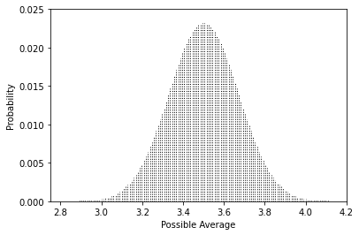

```python
average_probability_of_100_dice(100);
```

# 5) Show that the sum and average of an initially Gaussian distribution is also a Guassian (can be analytic or numerical). How does the standard deviation of the resulting sum or average Guassian change? This is a hugely important result. Explore what this means for integrating a signal over time.

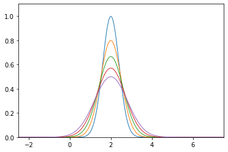

```python
fig, ax = plt.subplots(1,1)

#num = 1000
x = np.linspace(-10,10,1000)

#loc keyword specifies the mean
#scale keyword specifies standard deviation
ax.plot(x,stats.norm.pdf(x, loc = 2, scale = 0.4), linewidth = 1)
ax.plot(x,stats.norm.pdf(x, loc = 2, scale = 0.5), linewidth = 1)
ax.plot(x,stats.norm.pdf(x, loc = 2, scale = 0.6), linewidth = 1)
ax.plot(x,stats.norm.pdf(x, loc = 2, scale = 0.7), linewidth = 1)
ax.plot(x,stats.norm.pdf(x, loc = 2, scale = 0.8), linewidth = 1)

plt.xlim([-2.50,7.5])
plt.ylim([0,1.1])
plt.show()
```